# Making better use of openair (and friends)

30th April 2019

## The `openair` project

`openair` started about 10 years ago as a way in which to provide open source, dedicated data analysis tools for the air quality community

- Widely used internationally by academia, governmental bodies and the private sector
- Downloaded > 150,000 times
- Coded in R — a programming language developed for data analysis and statistics
- Lots of functions for air quality analysis including, directional analyses, robust trends, clustering of polar plots, back trajectories, easy access to AURN, SAQN, WAQN, KCL networks, …

## Approach to analysis

- In some ways it is useful to think in terms of a crime scene investigation
  - Perhaps it **is** a crime scene — air quality limits set in law exceeded, naughty vehicle manufacturers and lots of early deaths!
- Thinking more in terms of forensic science
  - Forensic scientists collect, preserve, and analyse scientific evidence during the course of an investigation
  - A *whodunnit* for air quality scientists — Mrs White in the library … or VW on the Old Kent Road
- Tricky for air quality because the ‘suspects’ do not have unique fingerprints or DNA
  - Although particle composition might be a close analogy …

## Asking questions of your data

General questions:

- What is it you really want to know?
- Are the measurements dominated by specific source(s)?
- What changes occur over time (trends)?
- How does site ‘X’ compare with other sites?
- Is there evidence that the measurements are affected by street canyons?

Harder questions:

- What is the contribution from road traffic emissions?
- How much are concentrations affected by non-local sources?
- When will site ‘X’ meet an air quality limit?

## Conditional analysis is useful

- Don’t need to analyse the full data set
- Filter data for conditions of interest
  - Focus on weekdays, and certain hours e.g. 7 am to 7 pm for traffic data
  - Certain months of the year
  - Other data e.g. vehicle flows
  - Geographic areas
  - By wind direction and wind speed
  - Trends — don’t have to consider *all* data if question is about recent changes
- Trade off: more filtering \(\Rightarrow\) less data
  - Considering uncertainties can be useful

## Example of Oxford roadside site

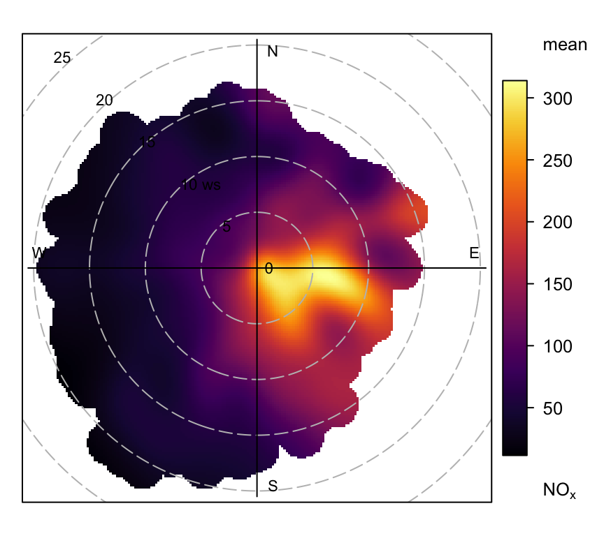

```r
library(openair)
oxford <- importAURN(site = "ox", year = 2010:2018)

polarPlot(oxford, pollutant = "nox", cols = "inferno")
```

## Cluster analysis

- Can be tricky to filter data by ‘eyeballing’
- Use clustering instead

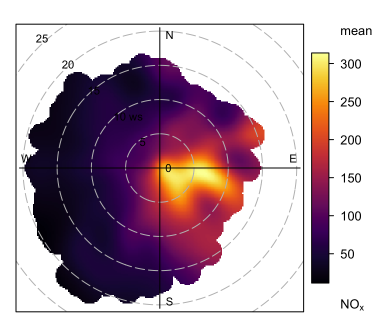

```r
results <- polarCluster(
  oxford, pollutant = "nox",
  n.clusters = 4, cols = "Set1"
  )
```

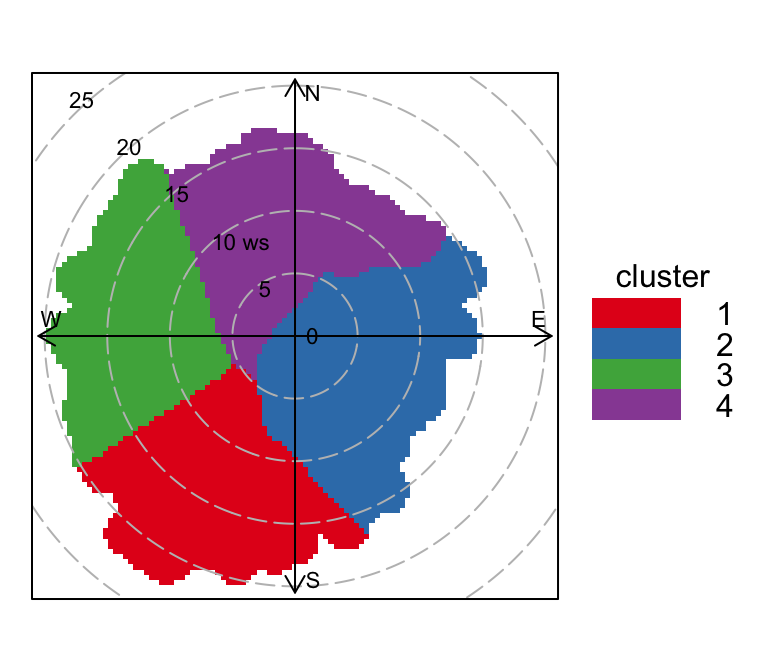

## Temporal variations by cluster

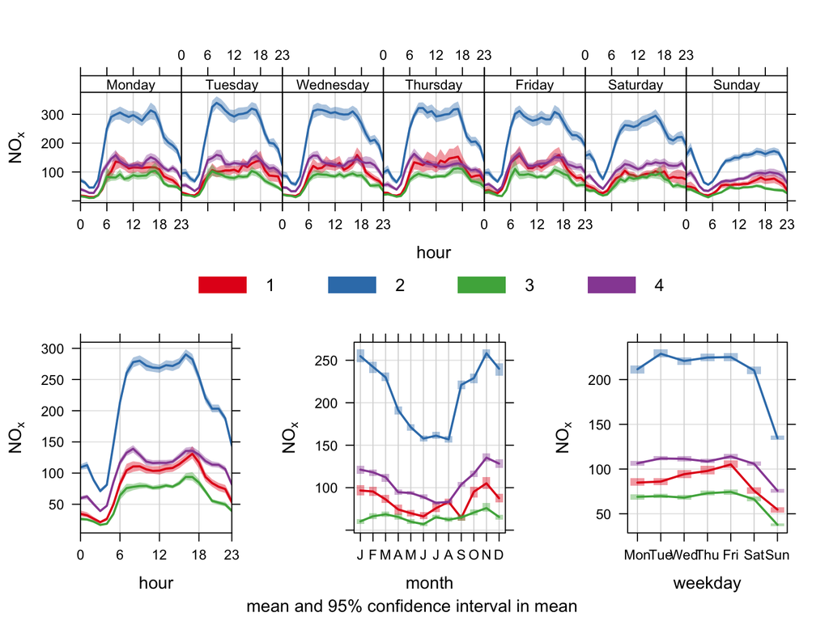

## Trends by cluster

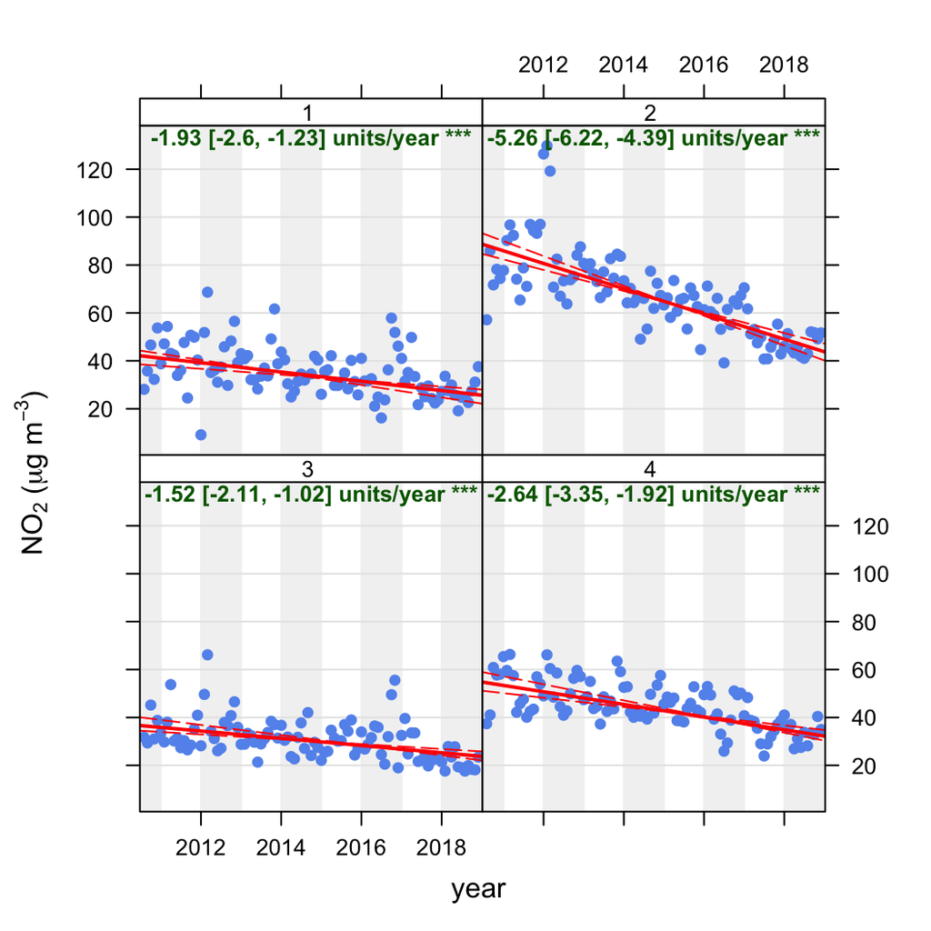

## Closer look at Cluster 2 (road source)

- Some evidence that concentrations have levelled off recently
- Smooth trends are useful in this respect — not all data should have a straight-line trend calculated

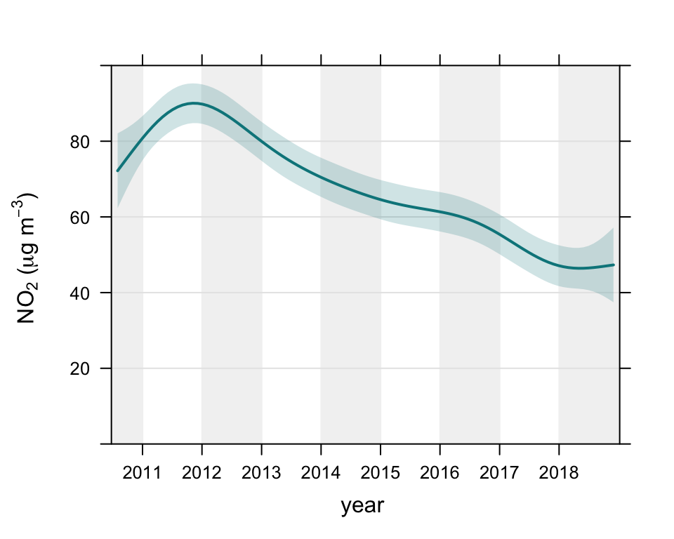

## Extensions to openair

- `openair` itself has not changed hugely over the past few years
- Preference is to have other focused packages that deal with particular things
- `worldmet` for accessing meteorological data
- `openairmaps` for polar plots on interactive maps (still a bit developmental), see https://github.com/davidcarslaw/openairmaps
- Polly’s `aqtrends` package you have already heard about
- Stuart Grange’s `rmweather` package to remove the meteorological variation from air quality data, see https://github.com/skgrange/rmweather

## Access to met data

- `importAURN` since about 2010 uses a numerical model (WRF) to provide wind speed and direction
- `importKCL` with option `met = TRUE` gives a London ‘mean’ value based on surface measurements
- R packages exist to access data from the likes of NOAA’s Integrated Surface Database (ISD)

```r
library(worldmet)

# search for 100 nearest met sites based on lat/lon
getMeta(lat = 51.5, lon = -0.5, n = 100)
```

- Typically two 10-minute periods in the hour, so not full hourly

## Better access to met data

[interactive chart not shown]

## Data from Heathrow in 2019

```r
met <- importNOAA(year = 2019)
met
```

```
## # A tibble: 2,710 x 23
##    date                usaf  wban  code  station   lat    lon  elev    wd    ws ceil_hgt visibility
##    <dttm>              <chr> <chr> <chr> <chr>   <dbl>  <dbl> <dbl> <dbl> <dbl>    <dbl>      <dbl>
##  1 2019-01-01 00:00:00 0377… 99999 0377… HEATHR…  51.5 -0.457    25  284.  3.27     657.      22000
##  2 2019-01-01 01:00:00 0377… 99999 0377… HEATHR…  51.5 -0.457    25  287.  3.43     667.      28000
##  3 2019-01-01 02:00:00 0377… 99999 0377… HEATHR…  51.5 -0.457    25  290   4.1      728       45000
##  4 2019-01-01 03:00:00 0377… 99999 0377… HEATHR…  51.5 -0.457    25  290   3.43     768       45000
##  5 2019-01-01 04:00:00 0377… 99999 0377… HEATHR…  51.5 -0.457    25  276.  3.27     778.      35000
##  6 2019-01-01 05:00:00 0377… 99999 0377… HEATHR…  51.5 -0.457    25  267.  2.77   14917.      35000
##  7 2019-01-01 06:00:00 0377… 99999 0377… HEATHR…  51.5 -0.457    25  265.  2.77   11503       28000
##  8 2019-01-01 07:00:00 0377… 99999 0377… HEATHR…  51.5 -0.457    25  273.  3.6      787.      23000
##  9 2019-01-01 08:00:00 0377… 99999 0377… HEATHR…  51.5 -0.457    25  274.  3.1      627.      30000
## 10 2019-01-01 09:00:00 0377… 99999 0377… HEATHR…  51.5 -0.457    25  275.  2.93     718       26000
## # … with 2,700 more rows, and 11 more variables: air_temp <dbl>, dew_point <dbl>, atmos_pres <dbl>,
## #   RH <dbl>, cl_1 <dbl>, cl_1_height <dbl>, cl_2 <dbl>, cl_2_height <dbl>, cl_3 <dbl>,
## #   cl_3_height <dbl>, cl <dbl>
```

## Polar plots on an interactive map

- `polarPlot`(s) on maps are useful for triangulating sources — especially in an industrial emissions context
- Evidence of a street canyon?
- Tough test of air quality models

```r
library(openairmaps)

polarMap(polar_data,
         latitude = "latitude", longitude = "longitude",
         type = "site",
         provider = "Stamen.Toner", cols = "inferno")
```

## Polar plots on an interactive map

[interactive chart not shown]

## Dominant meteorology

- Much of the time we are happy to analyse data as we find it i.e. strongly affected by the weather
- However, meteorology can mask or emphasise things we are interested in and can be misleading
  - Trends affected more by the weather than by changes in emissions
  - Detecting change — is it due to an intervention that affects emissions or by the weather?
  - Many sophisticated change-point methods but the elephant in the room is often meteorology
- Things would be much easier if the weather was the same every day!

## Example from the port of Dover

- Useful example considering SO<sub>2</sub> that can be related to fuel sulphur changes

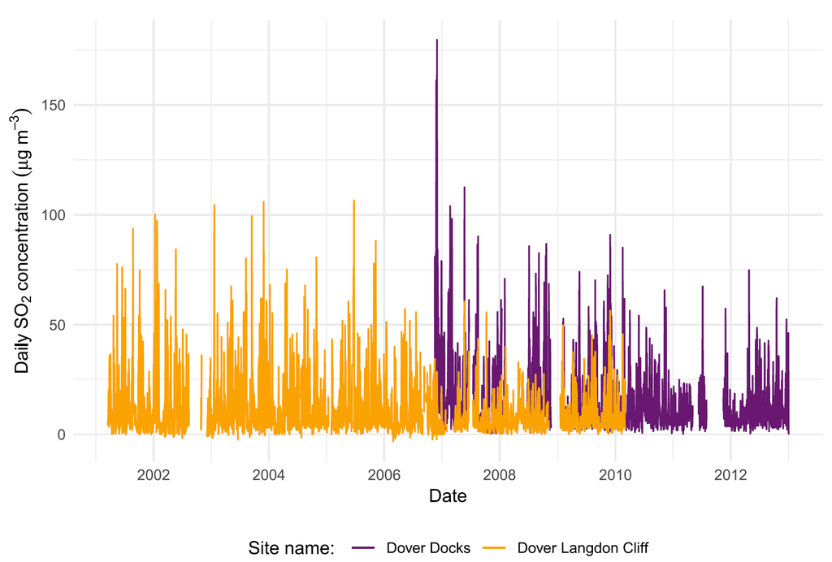

## Effects of meteorology ‘removed’

[figure not shown]

## Concluding remarks

- `openair` continues to develop but there has been a move towards producing smaller, more focused R packages
- No silver bullet for data analysis
  - Tools provide a rapid way of exploring data and asking questions of it
  - Guided by domain knowledge
  - Useful to learn from what others do
- Attend a training course to learn more!